# Intro to data exploration and visualization

SDS 323  
James Scott (UT-Austin)

### Types of features in a data set

Categorical: the answer to a multiple choice question:

- Chevy/Honda/Tesla
- ice cream/cake/pie

Ordinal: categorical, where the answers have an ordering but not a magnitude

- Poor, Moderate, Good, Great
- Private, Corporal, Lieutenant, Colonel, General

Numerical: numbers, whether integer or real-valued

- Beware the “faux numerical” ordinal scale

### The basics of data exploration

- Boxplots
- Scatter plots
- Line graphs
- Faceting
- Tables
- Grouping/piping/summarizing
- Bar plots
- Histograms/density plots

### Scatter plots

Here are several rows of a data frame about cars. Every row is a car. Every column is a feature describing the car.

```
# A tibble: 6 x 12
  manufacturer model displ  year   cyl trans drv     cty   hwy fl    class
  <chr>        <chr> <dbl> <int> <int> <chr> <chr> <int> <int> <chr> <chr>
1 ford         f150…   4.6  1999     8 manu… 4        13    16 r     pick…
2 toyota       camr…   2.4  2008     4 auto… f        22    31 r     comp…
3 ford         expe…   5.4  1999     8 auto… r        11    17 r     suv
4 hyundai      tibu…   2.7  2008     6 manu… f        16    24 r     subc…
5 nissan       path…   3.3  1999     6 manu… 4        15    17 r     suv
6 chevrolet    corv…   6.2  2008     8 manu… r        16    26 p     2sea…
# … with 1 more variable: orig.id <chr>
```

### Scatter plots

For numerical data, our workhorse is the humble scatter plot.

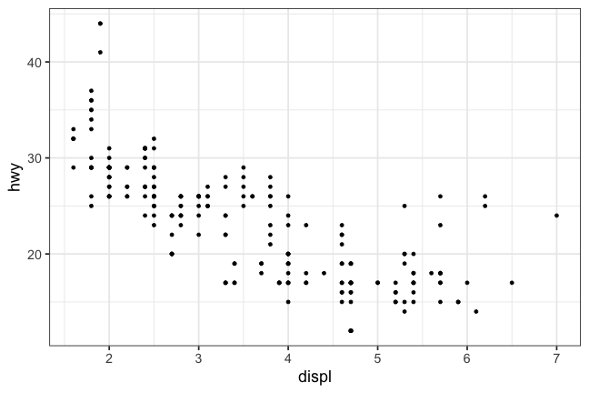

### Scatter plots

There are lots of strategies for enriching a scatter plot with additional information. We can color points according to a key…

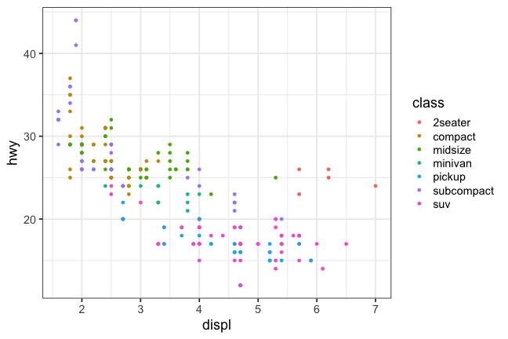

### Scatter plots: faceting

Or *facet* on a third variable…

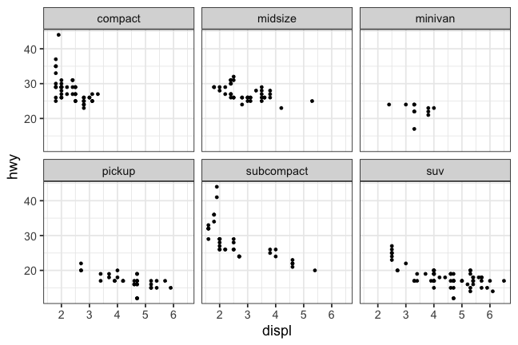

### Line graphs

When it's important to emphasize continuity of a set of points (e.g. over time), use a line graph.

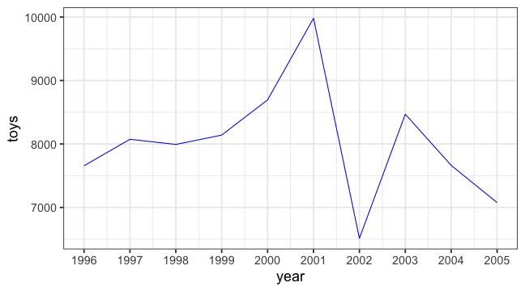

Total value of toy imports from the United Kingdom over time (thousands USD). Q: what might account for the big spikes?

### Line graphs

Actually, all those Harry Potter toys come from China…

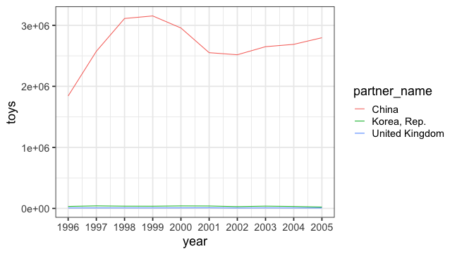

### Line graphs

This is what logarthimic scales were invented for :-)

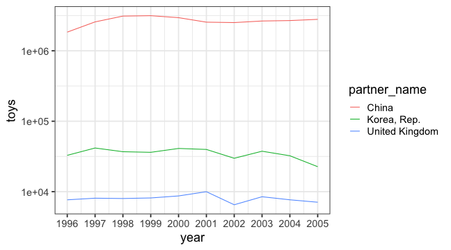

Note: OK not to start this \( y \) axis at 0, because we don't use height to judge relative size on a log scale.

### Tables

Here are the first several rows of a data frame about passengers on the Titanic. Every row is a passenger. Every column is a feature describing the passenger.

```
                             name survived    sex     age passengerClass
1   Allen, Miss. Elisabeth Walton      yes female 29.0000            1st
2  Allison, Master. Hudson Trevor      yes   male  0.9167            1st
3    Allison, Miss. Helen Loraine       no female  2.0000            1st
4 Allison, Mr. Hudson Joshua Crei       no   male 30.0000            1st
5 Allison, Mrs. Hudson J C (Bessi       no female 25.0000            1st
6             Anderson, Mr. Harry      yes   male 48.0000            1st
```

We see both categorical (sex, passengerClass, survived) and numerical (age) variables.

### Tables

A natural thing might be to cross-tabulate survival by passenger class:

```r
xtabs(~survived + passengerClass, data=TitanicSurvival)
```

```
        passengerClass
survived 1st 2nd 3rd
     no  123 158 528
     yes 200 119 181
```

We're literally just counting how many passengers have each combination of features. (If you know Excel: this is like a pivot table.)

### An aside: piping

A really useful operation is *piping.* Example:

```r
a = log(3)
b = exp(a)
c = sqrt(b)
c
```

```
[1] 1.732051
```

versus:

```r
a = log(3)
a %>% exp() %>% sqrt()
```

```
[1] 1.732051
```

### Tables

We can pipe our table to `prop.table` to standardize along the columns (`margin=2`):

```r
xtabs(~survived + passengerClass, data=TitanicSurvival) %>%
  prop.table(margin=2)
```

```
        passengerClass
survived       1st       2nd       3rd
     no  0.3808050 0.5703971 0.7447109
     yes 0.6191950 0.4296029 0.2552891
```

Now you can compare survival proportions by passenger class.

### Tables

Seven decimal places seems overkill – let's round to third decimal place by piping the the result to round:

```r
xtabs(~survived + passengerClass, data=TitanicSurvival) %>%
  prop.table(margin=2) %>%
  round(3)
```

```
        passengerClass
survived   1st   2nd   3rd
     no  0.381 0.570 0.745
     yes 0.619 0.430 0.255
```

### Tables

If you pipe the result to `kable`, you'll get a prettier table (formatted in Markdown):

```r
library(knitr)
xtabs(~survived + passengerClass, data=TitanicSurvival) %>%
  prop.table(margin=2) %>%
  round(3) %>%
  kable()
```

|  | 1st | 2nd | 3rd |
| --- | --- | --- | --- |
| no | 0.381 | 0.57 | 0.745 |
| yes | 0.619 | 0.43 | 0.255 |

### Bar plots

We can also turn this information into a bar plot.

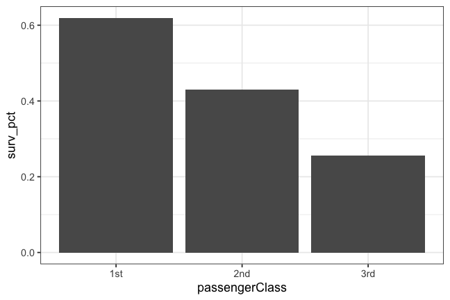

Remember to start your \( y \)-axis at 0!

### Grouping and summarizing

Another good use of tables is to display *summary statistics* of numerical variables. For example, here's how we'd use pipes to compute the average age by passenger class:

```r
TitanicSurvival %>%
  group_by(passengerClass) %>%
  summarize(mean_age = mean(age,na.rm=TRUE))
```

```
# A tibble: 3 x 2
  passengerClass mean_age
  <fct>             <dbl>
1 1st                39.2
2 2nd                29.5
3 3rd                24.8
```

Use `group_by` to group cases according to the `passengerClass` variable. Then compute a summary statistic by averaging `age`. (`na.rm = TRUE` tells R to ignore missing values.)

### Grouping and summarizing

Now with two variables defining the groups:

```r
TitanicSurvival %>%
  group_by(passengerClass, survived) %>%
  summarize(mean_age = mean(age,na.rm=TRUE))
```

```
# A tibble: 6 x 3
# Groups:   passengerClass [3]
  passengerClass survived mean_age
  <fct>          <fct>       <dbl>
1 1st            no           43.2
2 1st            yes          36.8
3 2nd            no           33.2
4 2nd            yes          24.9
5 3rd            no           26.0
6 3rd            yes          21.5
```

This gives us a “flat” table.

### Grouping and summarizing

If you want to un-flatten the table, use `spread`:

```r
TitanicSurvival %>%
  group_by(passengerClass, survived) %>%
  summarize(mean_age = mean(age,na.rm=TRUE)) %>%
  spread(survived, mean_age)
```

```
# A tibble: 3 x 3
# Groups:   passengerClass [3]
  passengerClass    no   yes
  <fct>          <dbl> <dbl>
1 1st             43.2  36.8
2 2nd             33.2  24.9
3 3rd             26.0  21.5
```

`spread` says to spread out the levels of the `survived` variables along the columns of the table and put the `mean_age` variable in each entry.

### Grouping and summarizing

You can compute lots of summary statistics this way:

```r
TitanicSurvival %>%
  group_by(passengerClass) %>%
  summarize(mean_age = mean(age,na.rm=TRUE),
            sd_age = sd(age,na.rm=TRUE),
            max_age = max(age,na.rm=TRUE))
```

```
# A tibble: 3 x 4
  passengerClass mean_age sd_age max_age
  <fct>             <dbl>  <dbl>   <dbl>
1 1st                39.2   14.5      80
2 2nd                29.5   13.6      70
3 3rd                24.8   12.0      74
```

### Histograms

Now let's say we wanted to look at the *full* distribution of ages on the Titanic (i.e. not just a summary like the average).

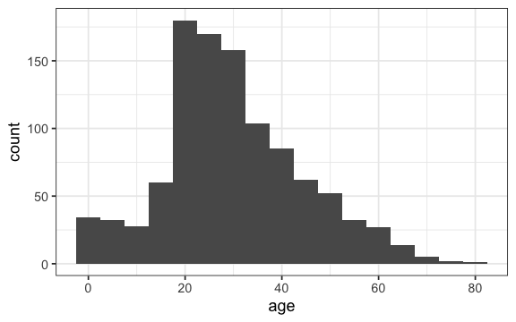

Our workhorse for this kind of thing is a histogram.

### Histograms

We can change the bin width on a histogram (here 1, versus 5):

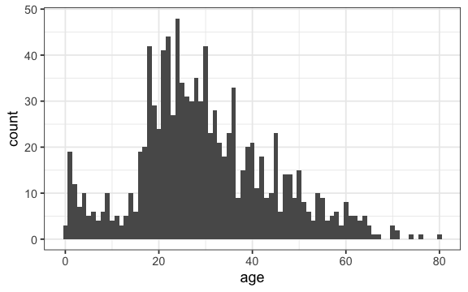

### Histograms

We can also normalize the total area to sum to 1:

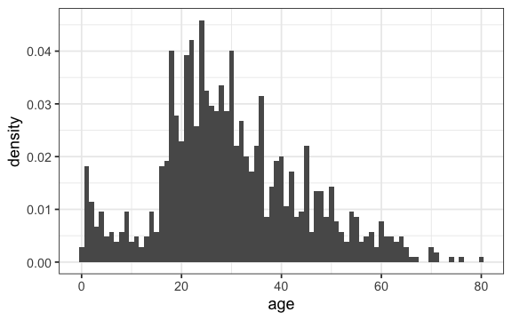

This is called a density histogram. It's like an estimated probability density.

### Histograms

We can also compare histograms across different levels of a categorical variable (recall this is *faceting*).

With raw counts, each histogram has a different total area.

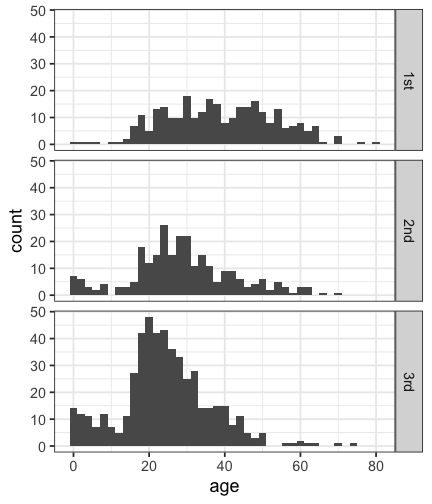

### Histograms

In density form.

Notice that now, each panel has total area 1.

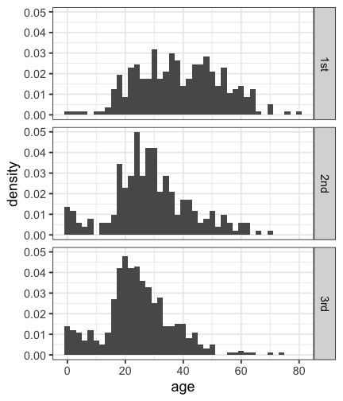

### Boxplots

Another way to compare data across categories is with a boxplot.

- Each box shows the median and first/third quartiles.
- By default, the whiskers extend 1.5 times the inter-quartile range. Points outside these are shown individually.

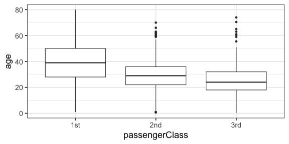

### Boxplots

Boxplots are preferred when there are lots of categories, because individual histograms can look cluttered.

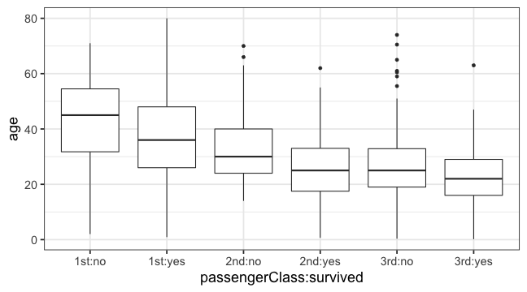

### Violin plots

A violin plot is a variant; it attempts to show a bit more of the shape of each distribution.

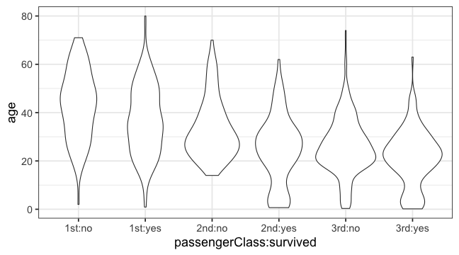

The width of the violin is kind of like the height of the histogram.

### Density plots

Another variant is the density plot, which is like a smooth version of a histogram:

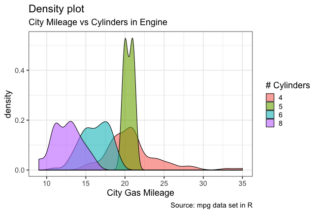

### Take-home skills

We've covered:

- data types (categorica/ordinal/numerical)
- cross tabulation and contingency tables
- some basic plots (bar charts, scatter plots, line graphs, histograms and their variations)
- basics of data workflow (pipe/group/summarize)

### To the code!

Let's look at the code examples in:

- `mpg.R`
- `titanic.R`
- `toyimports_linegraph.R`